# Kernza Data Wrangle Project Analysis

Christopher Sherve

2026-04-29

## Setup

Packages are loaded and data is read from Google Sheets. The `emmeans`, `multcomp`, and `multcompView` packages are loaded later immediately before the ANOVA section to avoid the MASS package masking `dplyr::select()`.

```r
library(tidyverse)
library(googlesheets4)
library(lubridate)
library(patchwork)
library(knitr)
library(lattice)

# Resolve MASS package conflict with dplyr
select <- dplyr::select
filter <- dplyr::filter

# Load corrected dataset from Google Sheets
data <- read_sheet(
  "https://docs.google.com/spreadsheets/d/1RZdL8GhR8bRt3f6G9pSMFs50jnjGvhdAajJhmgkZ0xs/edit?usp=sharing",
  sheet = "combined_clean_final_v2"
)
```

```r
data <- data %>%
  mutate(
    trt = factor(trt,
                 levels = c(21, 22, 25, 23),
                 labels = c("0 kg N", "60 kg N",
                            "Kernza/Alfalfa 40 kg N", "120 kg N")),
    year     = factor(year),
    location = factor(location),
    environment = paste(location, year, sep = "_")
  )
```

## Data Overview

The primary dataset (`combined_clean_final_v2`) integrates yield, lysimeter nitrate, soil moisture, and soil chemistry data from Waseca and Lamberton, MN across 2014 and 2015 (Years 3 and 4 of the study). Full data cleaning and QA/QC steps are documented in `data_wrangling.Rmd`, `metadata_kernza.md`, and `lysimeter_QAQC_findings.md`.

```r
glimpse(data)
```

```
## Rows: 64
## Columns: 34
## $ year             <fct> 2014, 2014, 2014, 2014, 2014, 2014, 2014, 2014, 2014,…
## $ location         <fct> Lamberton, Lamberton, Lamberton, Lamberton, Lamberton…
## $ plot             <dbl> 2106, 2111, 2116, 2121, 2203, 2213, 2218, 2223, 2304,…
## $ replicate        <dbl> 1, 1, 1, 1, 2, 2, 2, 2, 3, 3, 3, 3, 4, 4, 4, 4, 1, 1,…
## $ trt              <fct> Kernza/Alfalfa 40 kg N, 120 kg N, 60 kg N, 0 kg N, 60…
## $ crops            <chr> "TLI/leg", "TLI", "TLI", "TLI", "TLI", "TLI", "TLI/le…
## $ legume_inclusion <dbl> 1, 0, 0, 0, 0, 0, 1, 0, 0, 1, 0, 0, 0, 1, 0, 0, 0, 1,…
## $ n_fertilizer     <dbl> 40, 120, 60, 0, 60, 120, 40, 0, 120, 40, 60, 0, 0, 40…
## $ grain_yield      <dbl> 424, 264, 272, 88, 574, 542, 412, 268, 134, 386, 200,…
## $ iwg_straw_yield  <dbl> 10034, 10102, 11182, 5390, 13596, 15120, 9538, 8586, …
## $ legume_biomass   <dbl> 38.0, NA, NA, NA, NA, NA, 65.0, NA, NA, 75.0, NA, NA,…
## $ plant_height     <dbl> 146, 122, 130, 134, 153, 130, 144, 136, 154, 133, 140…
## $ lodging_score    <dbl> 2, 3, 2, 2, 2, 2, 2, 2, 4, 3, 3, 2, 2, 3, 3, 4, 5, 3,…
```

[output cut: 21 more lines]

```r
summary(data)
```

```
##    year         location       plot        replicate
##  2014:32   Lamberton:32   Min.   :1105   Min.   :1.00
##  2015:32   Waseca   :32   1st Qu.:1283   1st Qu.:1.75
##                           Median :1764   Median :2.50
##                           Mean   :1763   Mean   :2.50
##                           3rd Qu.:2243   3rd Qu.:3.25
##                           Max.   :2422   Max.   :4.00
##
##                      trt        crops           legume_inclusion  n_fertilizer
##  0 kg N                :16   Length:64          Min.   :0.00     Min.   :  0
##  60 kg N               :16   Class :character   1st Qu.:0.00     1st Qu.: 30
##  Kernza/Alfalfa 40 kg N:16   Mode  :character   Median :0.00     Median : 50
##  120 kg N              :16                      Mean   :0.25     Mean   : 55
##                                                 3rd Qu.:0.25     3rd Qu.: 75
##                                                 Max.   :1.00     Max.   :120
##
##   grain_yield     iwg_straw_yield legume_biomass    plant_height
##  Min.   : 14.00   Min.   : 4224   Min.   :  0.00   Min.   :111.0
##  1st Qu.: 53.36   1st Qu.: 6996   1st Qu.: 18.52   1st Qu.:128.5
##  Median :120.40   Median : 8996   Median : 58.50   Median :136.5
##  Mean   :161.73   Mean   : 8579   Mean   :110.63   Mean   :135.8
##  3rd Qu.:255.81   3rd Qu.:10102   3rd Qu.:129.75   3rd Qu.:141.2
##  Max.   :574.00   Max.   :15120   Max.   :556.00   Max.   :163.0
##  NA's   :2        NA's   :3       NA's   :48
##  lodging_score    NO3_mean_mgL    n_raw_readings   n_bdl_readings
##  Min.   :0.000   Min.   :0.0500   Min.   : 3.000   Min.   : 0.000
##  1st Qu.:2.000   1st Qu.:0.1343   1st Qu.: 5.000   1st Qu.: 1.750
##  Median :3.000   Median :0.2610   Median : 5.000   Median : 2.500
##  Mean   :3.219   Mean   :0.6625   Mean   : 6.688   Mean   : 3.391
##  3rd Qu.:5.000   3rd Qu.:0.5844   3rd Qu.: 9.000   3rd Qu.: 5.250
##  Max.   :7.000   Max.   :4.0394   Max.   :10.000   Max.   :10.000
##
##  pct_bdl_readings    any_bdl        majority_bdl       vwc_50cm
##  Min.   :  0.00   Min.   :0.0000   Min.   :0.0000   Min.   :0.1381
##  1st Qu.: 25.00   1st Qu.:1.0000   1st Qu.:0.0000   1st Qu.:0.2185
##  Median : 40.00   Median :1.0000   Median :0.0000   Median :0.2584
##  Mean   : 46.49   Mean   :0.9219   Mean   :0.4375   Mean   :0.2515
##  3rd Qu.: 66.70   3rd Qu.:1.0000   3rd Qu.:1.0000   3rd Qu.:0.2929
##  Max.   :100.00   Max.   :1.0000   Max.   :1.0000   Max.   :0.3661
##                                                     NA's   :16
```

[output cut: 17 more lines]

```
##  Min.   :2.100   Min.   :1.000    Min.   :1.463   Min.   :0.809
##  1st Qu.:2.850   1st Qu.:1.400    1st Qu.:2.036   1st Qu.:1.173
##  Median :3.250   Median :1.700    Median :2.481   Median :1.323
##  Mean   :3.131   Mean   :1.741    Mean   :2.377   Mean   :1.323
##  3rd Qu.:3.400   3rd Qu.:1.900    3rd Qu.:2.697   3rd Qu.:1.502
##  Max.   :4.000   Max.   :2.800    Max.   :3.196   Max.   :1.841
##  NA's   :32      NA's   :32       NA's   :34      NA's   :32
##  TOC_pct_18_30    environment
##  Min.   :0.3360   Length:64
##  1st Qu.:0.6438   Class :character
##  Median :0.7765   Mode  :character
##  Mean   :1.0048
##  3rd Qu.:1.2463
##  Max.   :2.3250
##  NA's   :32
```

## Data Limitations

The following limitations were identified during data wrangling and QA/QC and shape the interpretation of the analyses that follow:

1. **Soil organic matter at depth** Loss-on-ignition organic matter is only available at 0-6 inch depth for 2014 (Agvise Laboratories). Deeper depths (6-18” and 18-30”) are available for 2015 only
2. **Soil moisture in control plots** The was no data collected for the control treatment plots (trt 21, 0 kg N) by design. VWC data unavailable for 16 plots, preventing full assessment of moisture × N rate interactions.
3. **Lysimeter data interpretation** Lysimeters measure NO3 concentration in soil water at 100cm depth. August 2014 is absent due to harvest logistics. For these reasons formal statistical analysis of lysimeter data is not performed.
4. **Nitrogen budget in intercrop plots** The intercrop treatment receives 40 kg N ha⁻¹ of synthetic fertilizer plus variable additional nitrogen from alfalfa biological fixation. Timing of N availability cannot be quantified.

## Exploratory Visualizations

### Grain Yield by Treatment, Location, and Year

Grain yield was compared across four treatments and two years. Waseca and Lamberton are shown as separate panels to reveal the site × year interaction. Error bars show ± 1 standard error (n = 4 plots per treatment per location).

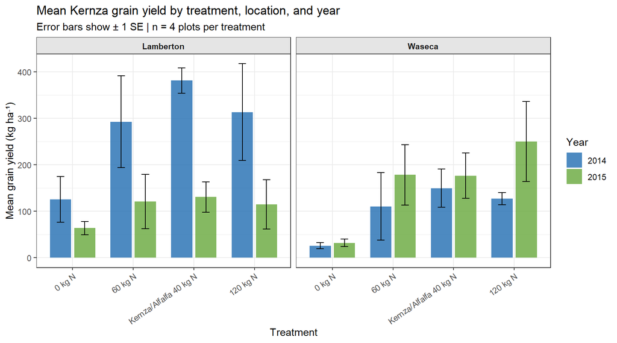

```r
yield_summary <- data %>%
  group_by(location, trt, year) %>%
  summarise(
    mean_yield = mean(grain_yield, na.rm = TRUE),
    se_yield   = sd(grain_yield, na.rm = TRUE) / sqrt(n()),
    .groups = 'drop'
  )

ggplot(yield_summary, aes(x = trt, y = mean_yield, fill = year)) +
  geom_bar(stat = "identity", position = position_dodge(0.8),
           width = 0.7, alpha = 0.85) +
  geom_errorbar(aes(ymin = mean_yield - se_yield,
                    ymax = mean_yield + se_yield),
                position = position_dodge(0.8), width = 0.25) +
  facet_wrap(~location) +
  scale_fill_manual(values = c("2014" = "#2E75B6", "2015" = "#70AD47")) +
  labs(
    title    = "Mean Kernza grain yield by treatment, location, and year",
    subtitle = "Error bars show ± 1 SE | n = 4 plots per treatment",
    x        = "Treatment",
    y        = "Mean grain yield (kg ha⁻¹)",
    fill     = "Year") +
  theme_bw() +
  theme(
    axis.text.x      = element_text(angle = 35, hjust = 1),
    strip.background = element_rect(fill = "grey90"),
    strip.text       = element_text(face = "bold"))
```

### Grain Yield and Lodging by Treatment, Location, and Year

To evaluate whether lodging contributed to yield differences between years mean grain yield and lodging score are plotted together. If lodging caused yield decline, sites with higher lodging should show lower yield. Waseca shows the opposite pattern where yield increased from 2014 to 2015 despite increasing lodging scores and ruling out lodging as the primary cause of the Waseca yield improvement.

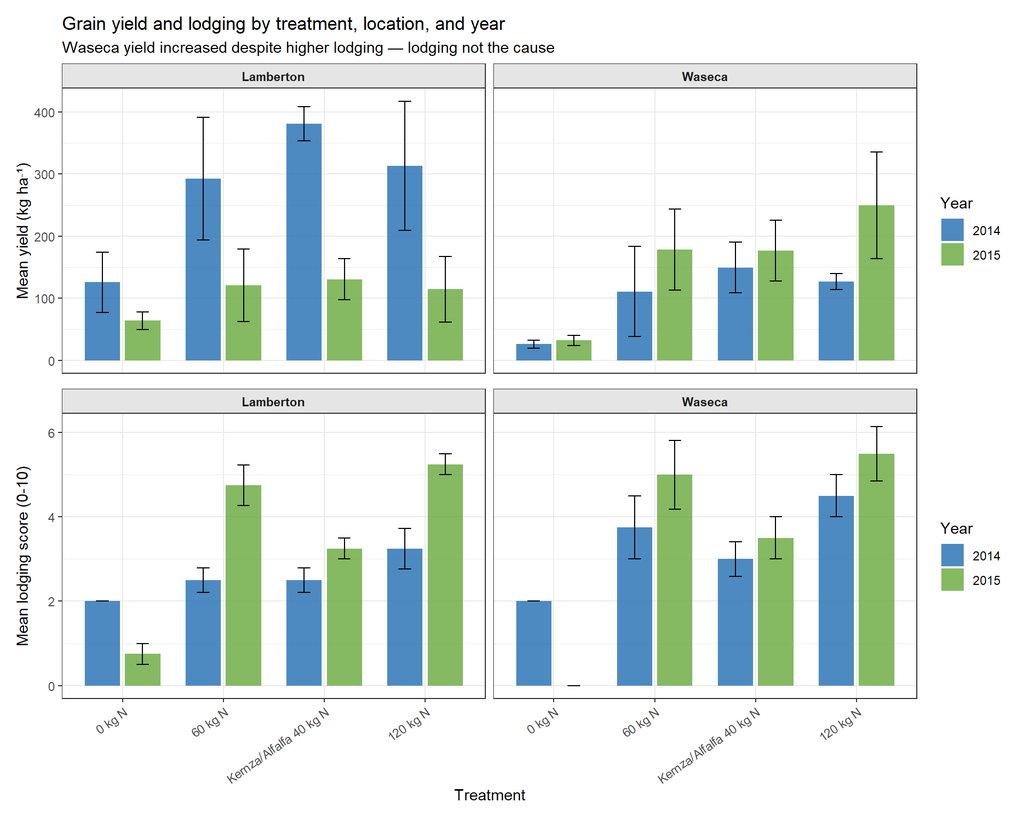

```r
yield_lodging_plot <- data %>%
  group_by(location, trt, year) %>%
  summarise(
    mean_yield   = mean(grain_yield, na.rm = TRUE),
    se_yield     = sd(grain_yield, na.rm = TRUE) / sqrt(n()),
    mean_lodging = mean(lodging_score, na.rm = TRUE),
    se_lodging   = sd(lodging_score, na.rm = TRUE) / sqrt(n()),
    .groups = 'drop'
  )

p1 <- ggplot(yield_lodging_plot,
             aes(x = trt, y = mean_yield, fill = year)) +
  geom_bar(stat = "identity", position = position_dodge(0.8),
           width = 0.7, alpha = 0.85) +
  geom_errorbar(aes(ymin = mean_yield - se_yield,
                    ymax = mean_yield + se_yield),
                position = position_dodge(0.8), width = 0.25) +
  facet_wrap(~location) +
  scale_fill_manual(values = c("2014" = "#2E75B6", "2015" = "#70AD47")) +
  labs(title    = "Grain yield and lodging by treatment, location, and year",
       subtitle = "Waseca yield increased despite higher lodging — lodging not the cause",
       x        = NULL,
       y        = "Mean yield (kg ha⁻¹)",
       fill     = "Year") +
  theme_bw() +
  theme(
    axis.text.x      = element_blank(),
    axis.ticks.x     = element_blank(),
    strip.background = element_rect(fill = "grey90"),
    strip.text       = element_text(face = "bold"))

p2 <- ggplot(yield_lodging_plot,
             aes(x = trt, y = mean_lodging, fill = year)) +
  geom_bar(stat = "identity", position = position_dodge(0.8),
           width = 0.7, alpha = 0.85) +
  geom_errorbar(aes(ymin = mean_lodging - se_lodging,
                    ymax = mean_lodging + se_lodging),
                position = position_dodge(0.8), width = 0.25) +
  facet_wrap(~location) +
  scale_fill_manual(values = c("2014" = "#2E75B6", "2015" = "#70AD47")) +
  labs(x    = "Treatment",
       y    = "Mean lodging score (0-10)",
       fill = "Year") +
  theme_bw() +
  theme(
    axis.text.x      = element_text(angle = 35, hjust = 1),
    strip.background = element_rect(fill = "grey90"),
    strip.text       = element_text(face = "bold"))

p1 / p2
```

### Soil Water NO3 at 100cm Depth Exploratory Only

Lysimeter NO3 concentrations (mg/L) from soil water samples at 100cm depth are shown below as exploratory context. Statistical analysis is not performed on this data due to the limitations noted above (single depth, concentration, seasonal averaging, August 2014 gap, and high below detection limit (BDL) frequency. Patterns suggest site differences between Waseca and Lamberton but should be interpreted cautiously.

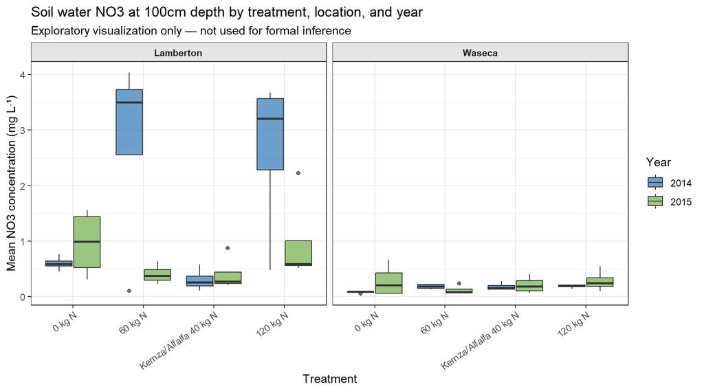

```r
ggplot(data, aes(x = trt, y = NO3_mean_mgL, fill = year)) +
  geom_boxplot(alpha = 0.7, position = position_dodge(0.8)) +
  facet_wrap(~location) +
  scale_fill_manual(values = c("2014" = "#2E75B6", "2015" = "#70AD47")) +
  labs(
    title    = "Soil water NO3 at 100cm depth by treatment, location, and year",
    subtitle = "Exploratory visualization only — not used for formal inference",
    x        = "Treatment",
    y        = "Mean NO3 concentration (mg L⁻¹)",
    fill     = "Year") +
  theme_bw() +
  theme(
    axis.text.x      = element_text(angle = 35, hjust = 1),
    strip.background = element_rect(fill = "grey90"),
    strip.text       = element_text(face = "bold"))
```

### Soil Moisture Field Map

Seasonal mean volumetric water content (VWC) is displayed as a spatial field map by plot, treatment, depth, location, and year. Each cell represents one plot colored by its seasonal mean moisture. Grey cells labeled “NS” indicate no sensor data was available in the 0 kg N control treatment. There seems to be a bit of spatial variation which is exhibited by the blocking.

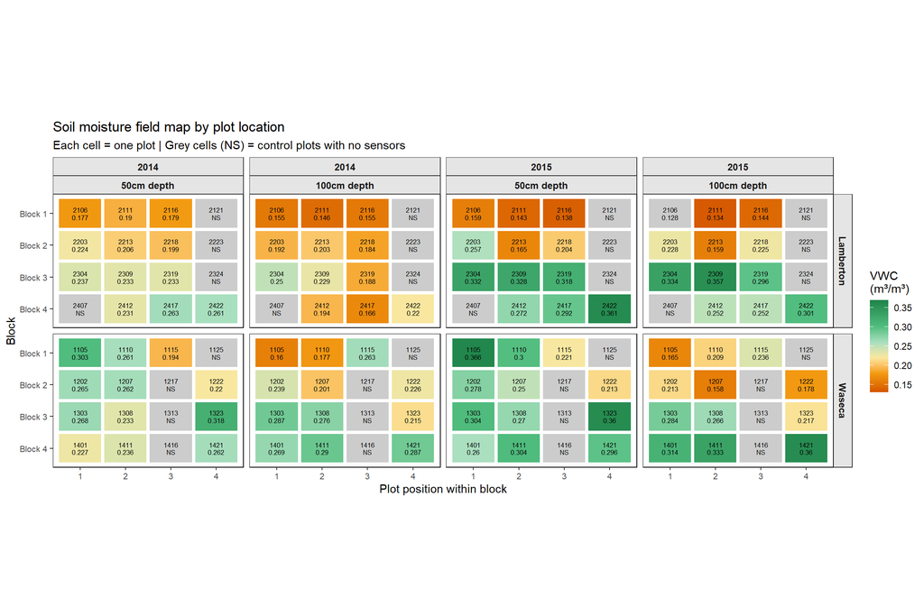

```r
moisture_field_map <- data %>%
  dplyr::select(year, location, plot, replicate, trt,
                vwc_50cm, vwc_100cm) %>%
  pivot_longer(cols = c(vwc_50cm, vwc_100cm),
               names_to  = "depth",
               values_to = "vwc") %>%
  mutate(
    depth = recode(depth,
                   "vwc_50cm"  = "50cm depth",
                   "vwc_100cm" = "100cm depth"),
    depth = factor(depth, levels = c("50cm depth", "100cm depth")),
    block = paste("Block", replicate)
  ) %>%
  group_by(location, year, depth, block) %>%
  arrange(plot) %>%
  mutate(plot_position = row_number()) %>%
  ungroup()

ggplot(moisture_field_map,
       aes(x = factor(plot_position),
           y = fct_rev(factor(block)),
           fill = vwc)) +
  geom_tile(color = "white", linewidth = 1.5) +
  geom_text(aes(label = paste0(plot, "\n",
                                ifelse(is.na(vwc), "NS",
                                       round(vwc, 3)))),
            size = 2.3, lineheight = 0.9) +
  facet_grid(location ~ year + depth) +
  scale_fill_gradientn(
    colors   = c("#D35400", "#F39C12", "#F9E79F",
                 "#A9DFBF", "#52BE80", "#1E8449"),
    values   = scales::rescale(c(0.13, 0.18, 0.22, 0.26, 0.30, 0.37)),
    limits   = c(0.13, 0.37),
    na.value = "grey80",
    name     = "VWC\n(m³/m³)",
    breaks   = c(0.15, 0.20, 0.25, 0.30, 0.35)) +
  labs(
    title    = "Soil moisture field map by plot location",
    subtitle = "Each cell = one plot | Grey cells (NS) = control plots with no sensors",
    x        = "Plot position within block",
    y        = "Block") +
  theme_bw() +
  theme(
    strip.background = element_rect(fill = "grey90"),
    strip.text       = element_text(face = "bold", size = 9),
    axis.text        = element_text(size = 8),
    panel.grid       = element_blank(),
    panel.border     = element_rect(color = "black", linewidth = 0.5),
    legend.position  = "right",
    aspect.ratio     = 0.7)
```

### Spatial Relationship Moisture, Yield, and Treatment

This three-layer visualization combines soil moisture (tile color), grain yield (circle size), and treatment (circle color) in the same spatial field layout. This allows simultaneous examination of moisture patterns, yield variation, and treatment effects at the plot level.

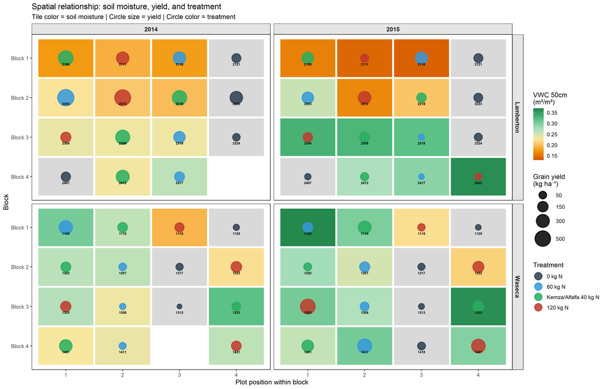

```r
moisture_yield_trt_map <- data %>%
  dplyr::select(year, location, plot, replicate, trt,
                vwc_50cm, grain_yield) %>%
  mutate(block = paste("Block", replicate)) %>%
  group_by(location, year, block) %>%
  arrange(plot) %>%
  mutate(plot_position = row_number()) %>%
  ungroup() %>%
  filter(!is.na(grain_yield))

ggplot(moisture_yield_trt_map,
       aes(x = factor(plot_position),
           y = fct_rev(factor(block)))) +
  geom_tile(aes(fill = vwc_50cm), color = "white", linewidth = 1.5) +
  geom_point(aes(size = grain_yield, color = trt),
             alpha = 0.85, stroke = 1.2) +
  geom_text(aes(label = plot),
            size = 2, color = "black",
            fontface = "bold", vjust = 2.8) +
  facet_grid(location ~ year) +
  scale_fill_gradientn(
    colors   = c("#D35400", "#F39C12", "#F9E79F",
                 "#A9DFBF", "#52BE80", "#1E8449"),
    limits   = c(0.13, 0.37),
    na.value = "grey85",
    name     = "VWC 50cm\n(m³/m³)") +
  scale_color_manual(values = c(
    "0 kg N"                 = "#2C3E50",
    "60 kg N"                = "#3498DB",
    "Kernza/Alfalfa 40 kg N" = "#27AE60",
    "120 kg N"               = "#C0392B"),
    name = "Treatment") +
  scale_size_continuous(
    range = c(3, 12),
    name  = "Grain yield\n(kg ha⁻¹)",
    breaks = c(50, 150, 300, 500)) +
  labs(
    title    = "Spatial relationship: soil moisture, yield, and treatment",
    subtitle = "Tile color = soil moisture | Circle size = yield | Circle color = treatment",
    x        = "Plot position within block",
    y        = "Block") +
  theme_bw() +
  theme(
    strip.background = element_rect(fill = "grey90"),
    strip.text       = element_text(face = "bold", size = 10),
    panel.grid       = element_blank(),
    panel.border     = element_rect(color = "black", linewidth = 0.5),
    legend.position  = "right",
    legend.box       = "vertical") +
  guides(
    fill  = guide_colorbar(order = 1),
    size  = guide_legend(order = 2),
    color = guide_legend(order = 3, override.aes = list(size = 5)))
```

## ANOVA Research Questions

Packages for post-hoc comparisons are loaded here to avoid the MASS package masking `dplyr::select()` earlier in the document.

```r
library(emmeans)
library(multcomp)
library(multcompView)
```

### ANOVA Question 1: Does treatment affect grain yield and does this interact with environment?

**Hypothesis:** The four treatments (0 kg N, 60 kg N, 120 kg N, and Kernza/Alfalfa 40 kg N intercrop) will produce different grain yields, and this effect will vary by environment (location × year). Specifically: - N fertilizer rate is expected to increase yield up to some optimized point - The intercrop treatment is hypothesized to perform similarly or better than 60 kg N and 120 kg N through N fixation by alfalfa. - Optimizing nitrogen treatment for IWG is also being tested.  
- The intercrop advantage may diminish by year 4 (2015) as competition with the aging Kernza stand increases

```r
model1 <- aov(grain_yield ~ trt * location * year, data = data)
summary(model1)
```

```
##                   Df Sum Sq Mean Sq F value  Pr(>F)
## trt                3 197330   65777   5.161 0.00370 **
## location           1  53087   53087   4.165 0.04702 *
## year               1  49754   49754   3.904 0.05419 .
## trt:location       3  11725    3908   0.307 0.82043
## trt:year           3  18368    6123   0.480 0.69751
## location:year      1 199598  199598  15.661 0.00026 ***
## trt:location:year  3  34280   11427   0.897 0.45016
## Residuals         46 586264   12745
## ---
## Signif. codes:  0 '***' 0.001 '**' 0.01 '*' 0.05 '.' 0.1 ' ' 1
## 2 observations deleted due to missingness
```

```r
em1 <- emmeans(model1, ~ trt | location * year)
cld(em1, Letters = letters)
```

```
## location = Lamberton, year = 2014:
##  trt                    emmean   SE df lower.CL upper.CL .group
##  0 kg N                  125.5 56.4 46   11.879      239  a
##  60 kg N                 292.5 56.4 46  178.879      406  ab
##  120 kg N                313.3 65.2 46  182.135      445  ab
##  Kernza/Alfalfa 40 kg N  381.0 56.4 46  267.379      495   b
##
## location = Waseca, year = 2014:
##  trt                    emmean   SE df lower.CL upper.CL .group
##  0 kg N                   26.0 65.2 46 -105.198      157  a
##  60 kg N                 110.5 56.4 46   -3.121      224  a
##  120 kg N                127.0 56.4 46   13.379      241  a
##  Kernza/Alfalfa 40 kg N  149.5 56.4 46   35.879      263  a
##
## location = Lamberton, year = 2015:
##  trt                    emmean   SE df lower.CL upper.CL .group
##  0 kg N                   63.7 56.4 46  -49.952      177  a
##  120 kg N                114.6 56.4 46    0.995      228  a
##  60 kg N                 121.0 56.4 46    7.355      235  a
##  Kernza/Alfalfa 40 kg N  130.5 56.4 46   16.898      244  a
##
## location = Waseca, year = 2015:
##  trt                    emmean   SE df lower.CL upper.CL .group
##  0 kg N                   32.2 56.4 46  -81.470      146  a
##  Kernza/Alfalfa 40 kg N  176.4 56.4 46   62.821      290  ab
##  60 kg N                 178.2 56.4 46   64.551      292  ab
##  120 kg N                249.8 56.4 46  136.201      363   b
##
## Confidence level used: 0.95
## P value adjustment: tukey method for comparing a family of 4 estimates
## significance level used: alpha = 0.05
## NOTE: If two or more means share the same grouping symbol,
##       then we cannot show them to be different.
##       But we also did not show them to be the same.
```

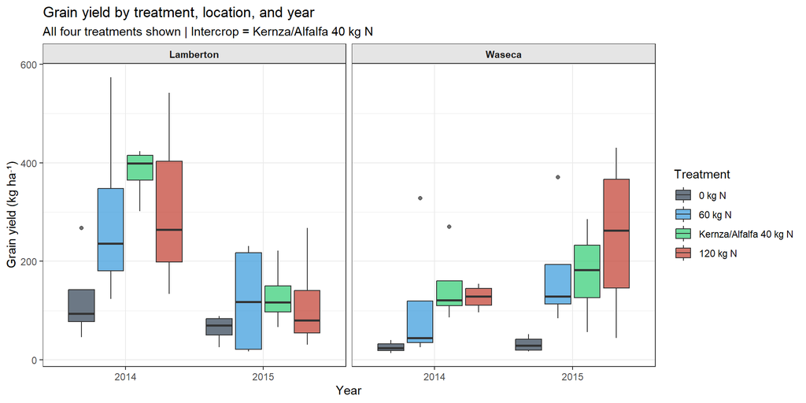

```r
data %>%
  ggplot(aes(x = factor(year), y = grain_yield, fill = trt)) +
  geom_boxplot(alpha = 0.7, position = position_dodge(0.85)) +
  facet_wrap(~location) +
  scale_fill_manual(values = c(
    "0 kg N"                 = "#2C3E50",
    "60 kg N"                = "#3498DB",
    "Kernza/Alfalfa 40 kg N" = "#2ECC71",
    "120 kg N"               = "#C0392B")) +
  labs(title    = "Grain yield by treatment, location, and year",
       subtitle = "All four treatments shown | Intercrop = Kernza/Alfalfa 40 kg N",
       x        = "Year",
       y        = "Grain yield (kg ha⁻¹)",
       fill     = "Treatment") +
  theme_bw() +
  theme(strip.background = element_rect(fill = "grey90"),
        strip.text       = element_text(face = "bold"),
        legend.position  = "right")
```

**Interpretation:** The ANOVA revealed two highly significant effects. The main effect of treatment (p = 0.0037) and the location × year interaction (p = 0.0003). The significant treatment effect confirms that the four treatments produced meaningfully different grain yields across the dataset. The location × year interaction reflects the opposite directional yield response between sites. Waseca yields increased from 2014 to 2015 while Lamberton yields decreased. The absence of a significant treatment × location or treatment × year interaction (p = 0.82 and p = 0.70 respectively) indicates that treatment effects were relatively consistent across environments.

The boxplot reveals several important patterns: the 0 kg N control consistently produced the lowest yields in all environments. N fertilizer rate generally increased yield with some diminishing returns at 120 kg N.  
The intercrop treatment (40 kg N synthetic + alfalfa N fixation) matched or exceeded the 120 kg N monoculture at Lamberton 2014, suggesting substantial alfalfa N contribution in the year 3 environment with highest yield potential.

**Supplementary 2-level analysis crop system effect:** For comparison, an additional ANOVA collapses the three N rate monoculture treatments (0, 60, 120 kg N) into a single “TLI monoculture” group to test whether the presence of a legume intercrop alone affects yield, independent of N rate variation.

```r
model1_crops <- aov(grain_yield ~ crops * location * year, data = data)
summary(model1_crops)
```

```
##                     Df Sum Sq Mean Sq F value   Pr(>F)
## crops                1  48927   48927   3.338 0.073214 .
## location             1  45673   45673   3.116 0.083170 .
## year                 1  51570   51570   3.519 0.066094 .
## crops:location       1   7994    7994   0.545 0.463400
## crops:year           1  15757   15757   1.075 0.304426
## location:year        1 184318  184318  12.576 0.000817 ***
## crops:location:year  1   4722    4722   0.322 0.572666
## Residuals           54 791448   14656
## ---
## Signif. codes:  0 '***' 0.001 '**' 0.01 '*' 0.05 '.' 0.1 ' ' 1
## 2 observations deleted due to missingness
```

```r
em1_crops <- emmeans(model1_crops, ~ crops | location * year)
cld(em1_crops, Letters = letters)
```

```
## location = Lamberton, year = 2014:
##  crops   emmean   SE df lower.CL upper.CL .group
##  TLI      237.5 36.5 54   164.27      311  a
##  TLI/leg  381.0 60.5 54   259.64      502   b
##
## location = Waseca, year = 2014:
##  crops   emmean   SE df lower.CL upper.CL .group
##  TLI       93.5 36.5 54    20.27      167  a
##  TLI/leg  149.5 60.5 54    28.14      271  a
##
## location = Lamberton, year = 2015:
##  crops   emmean   SE df lower.CL upper.CL .group
##  TLI       99.8 34.9 54    29.69      170  a
##  TLI/leg  130.5 60.5 54     9.16      252  a
##
## location = Waseca, year = 2015:
##  crops   emmean   SE df lower.CL upper.CL .group
##  TLI      153.4 34.9 54    83.32      223  a
##  TLI/leg  176.4 60.5 54    55.08      298  a
##
## Confidence level used: 0.95
## significance level used: alpha = 0.05
## NOTE: If two or more means share the same grouping symbol,
##       then we cannot show them to be different.
##       But we also did not show them to be the same.
```

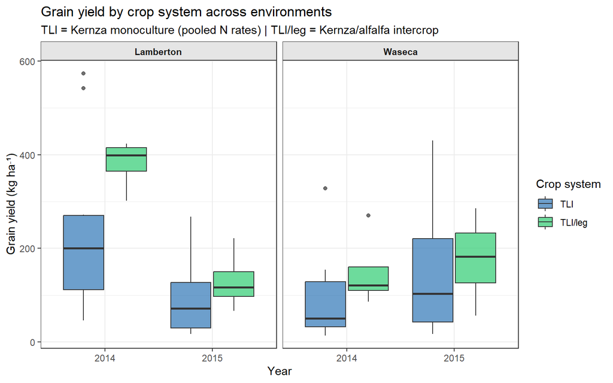

```r
data %>%
  ggplot(aes(x = factor(year), y = grain_yield, fill = crops)) +
  geom_boxplot(alpha = 0.7, position = position_dodge(0.8)) +
  facet_wrap(~location) +
  scale_fill_manual(values = c("TLI" = "#2E75B6",
                                "TLI/leg" = "#2ECC71")) +
  labs(title    = "Grain yield by crop system across environments",
       subtitle = "TLI = Kernza monoculture (pooled N rates) | TLI/leg = Kernza/alfalfa intercrop",
       x        = "Year",
       y        = "Grain yield (kg ha⁻¹)",
       fill     = "Crop system") +
  theme_bw() +
  theme(strip.background = element_rect(fill = "grey90"),
        strip.text       = element_text(face = "bold"))
```

Note that the crop system model shows a marginal effect (p = 0.073) compared to the highly significant full treatment model (p = 0.0037). The reduced statistical power reflects the fact that pooling the three N rates introduces substantial within-group variance, obscuring the clearer treatment-level effects visible in the 4-treatment analysis.

### ANOVA Question 2: Does plant height differ by treatment?

**Hypothesis:** Plant height will increase with nitrogen fertilizer rate as higher N availability promotes vegetative growth. The intercrop treatment may show different height dynamics due to competition with alfalfa.

```r
model2 <- aov(plant_height ~ trt * year*location, data = data)
summary(model2)
```

```
##                   Df Sum Sq Mean Sq F value   Pr(>F)
## trt                3 2483.8   827.9  12.771 2.93e-06 ***
## year               1  310.6   310.6   4.792   0.0335 *
## location           1  147.0   147.0   2.268   0.1386
## trt:year           3  339.2   113.1   1.744   0.1706
## trt:location       3  644.3   214.8   3.313   0.0277 *
## year:location      1   34.5    34.5   0.532   0.4691
## trt:year:location  3  346.3   115.4   1.781   0.1634
## Residuals         48 3111.7    64.8
## ---
## Signif. codes:  0 '***' 0.001 '**' 0.01 '*' 0.05 '.' 0.1 ' ' 1
```

```r
em2 <- emmeans(model2, ~ trt*year*location)
cld(em2, Letters = letters)
```

```
##  trt                    year location  emmean   SE df lower.CL upper.CL .group
##  0 kg N                 2015 Waseca       116 4.03 48      108      124  a
##  0 kg N                 2014 Waseca       123 4.03 48      115      131  ab
##  0 kg N                 2014 Lamberton    130 4.03 48      122      138  abc
##  120 kg N               2014 Waseca       132 4.03 48      123      140  abcd
##  60 kg N                2014 Waseca       132 4.03 48      124      140  abcd
##  0 kg N                 2015 Lamberton    132 4.03 48      124      140  abcd
##  120 kg N               2014 Lamberton    135 4.03 48      127      143  abcd
##  120 kg N               2015 Lamberton    137 4.03 48      129      145   bcd
##  Kernza/Alfalfa 40 kg N 2014 Lamberton    139 4.03 48      131      147   bcd
##  Kernza/Alfalfa 40 kg N 2014 Waseca       139 4.03 48      131      147   bcd
##  60 kg N                2015 Waseca       139 4.03 48      131      147   bcd
##  60 kg N                2014 Lamberton    140 4.03 48      132      148   bcd
##  60 kg N                2015 Lamberton    143 4.03 48      135      151   bcd
##  Kernza/Alfalfa 40 kg N 2015 Lamberton    143 4.03 48      135      151   bcd
##  Kernza/Alfalfa 40 kg N 2015 Waseca       144 4.03 48      135      152    cd
##  120 kg N               2015 Waseca       150 4.03 48      142      159     d
##
## Confidence level used: 0.95
## P value adjustment: tukey method for comparing a family of 16 estimates
## significance level used: alpha = 0.05
## NOTE: If two or more means share the same grouping symbol,
##       then we cannot show them to be different.
##       But we also did not show them to be the same.
```

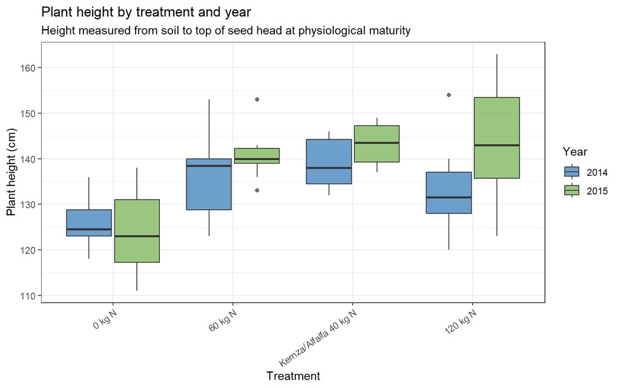

```r
ggplot(data, aes(x = trt, y = plant_height, fill = year)) +
  geom_boxplot(alpha = 0.7, position = position_dodge(0.8)) +
  scale_fill_manual(values = c("2014" = "#2E75B6", "2015" = "#70AD47")) +
  labs(title    = "Plant height by treatment and year",
       subtitle = "Height measured from soil to top of seed head at physiological maturity",
       x        = "Treatment",
       y        = "Plant height (cm)",
       fill     = "Year") +
  theme_bw() +
  theme(axis.text.x = element_text(angle = 35, hjust = 1))
```

**Interpretation:** it is significant that treatment of nitrogen application will improve plant height versus no nitrogen application. There is not a significant difference between the nitrogen applied treatments, but the intercropped treatment does have a higher averaged plant height than the monocropped treatments.  
I think the obvious question goes back to having a intercropped treatmnet that matches one of the monocropped treatments and comparing yield and plant height.

### Part 2 of ANOVA Question 2: Does plant height differ by treatment?

How well does plant height corrleate to yield in year 1 to year 2

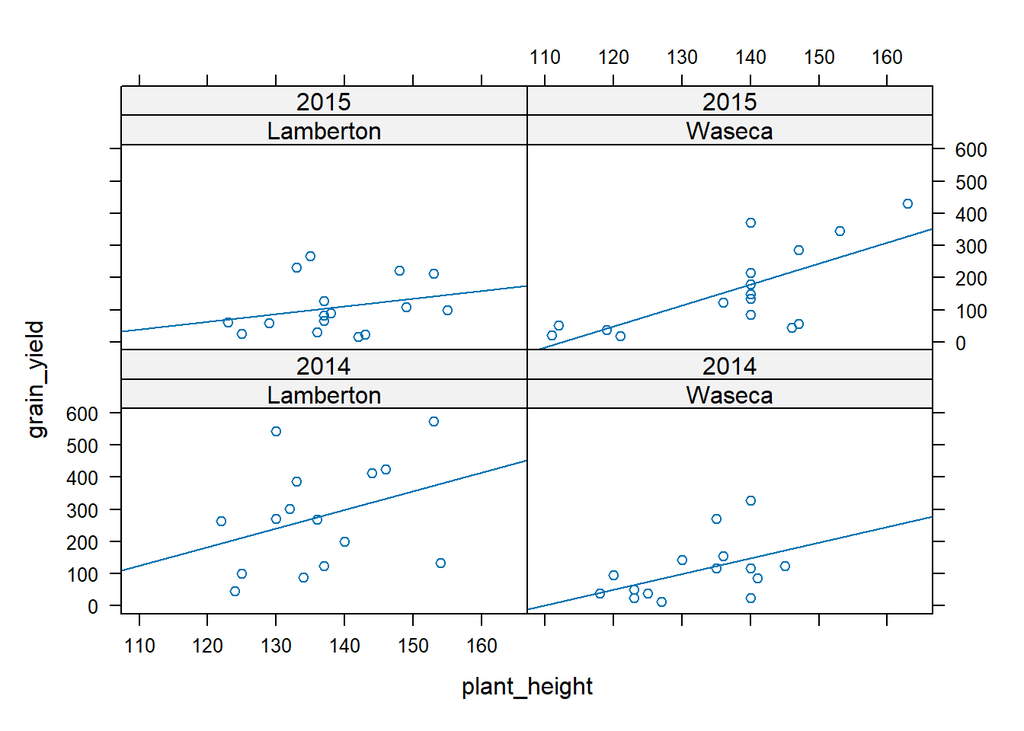

```r
xyplot(grain_yield ~ plant_height | location * year,
            data = data,
            type = c("p", "r"))
```

**Interpretation:** so while there is correlation between grain yield and plant height, the telling take away is the difference between locations in 2015.  
IWG behaves normally in Lamberton with good yield to plant height ration in 2014.  
The flood of 2014 in Waseca had a perfound effect on physiological status of the IWG plants because in 2015 the yield is opposite to normal year two yield behavior in IWG which is shown in Lamberton in 2015 where plant height stayed the same and yield decreased. This is important to note because the nutrient use is being limited by something and it is not plant height in this case.  
—

## Regression Research Questions

### Regression Question 1: Does grain yield increase with N fertilizer rate?

**Hypothesis:** Grain yield increases linearly with N fertilizer rate in Kernza monoculture plots. Based on Jungers et al. (2017) a quadratic relationship is also possible if yields decline at high N rates due to lodging. The linear model is tested first.

```r
reg1 <- lm(grain_yield ~ n_fertilizer+location, data = data_mono)

summary(reg1)
```

```
##
## Call:
## lm(formula = grain_yield ~ n_fertilizer + location, data = data_mono)
##
## Residuals:
##     Min      1Q  Median      3Q     Max
## -203.98  -72.07  -26.12   30.93  405.51
##
## Coefficients:
##                Estimate Std. Error t value Pr(>|t|)
## (Intercept)    102.1894    35.1823   2.905  0.00579 **
## n_fertilizer     1.1051     0.3939   2.805  0.00752 **
## locationWaseca -46.6552    38.1768  -1.222  0.22833
## ---
## Signif. codes:  0 '***' 0.001 '**' 0.01 '*' 0.05 '.' 0.1 ' ' 1
##
## Residual standard error: 129.3 on 43 degrees of freedom
##   (2 observations deleted due to missingness)
## Multiple R-squared:  0.1734, Adjusted R-squared:  0.1349
## F-statistic:  4.51 on 2 and 43 DF,  p-value: 0.01667
```

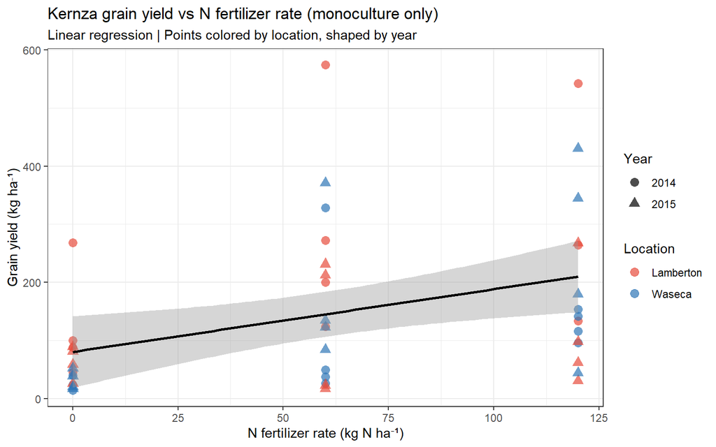

```r
ggplot(data_mono, aes(x = n_fertilizer, y = grain_yield)) +
  geom_point(aes(color = location, shape = year), size = 3, alpha = 0.7) +
  geom_smooth(method = "lm", se = TRUE, color = "black", linewidth = 1) +
  scale_color_manual(values = c("Waseca" = "#2E75B6",
                                 "Lamberton" = "#E74C3C")) +
  labs(
    title    = "Kernza grain yield vs N fertilizer rate (monoculture only)",
    subtitle = "Linear regression | Points colored by location, shaped by year",
    x        = "N fertilizer rate (kg N ha⁻¹)",
    y        = "Grain yield (kg ha⁻¹)",
    color    = "Location",
    shape    = "Year") +
  theme_bw()
```

**Supplementary regression (Lamberton only):** Because Waseca 2014 experienced documented historic flooding (Minnesota DNR 2014; 12.31 inches of rainfall in June, the wettest month in Minnesota state history) that suppressed reproductive development independently of N rate, a Lamberton-only supplementary regression provides a cleaner test of typical Kernza N response under non-extreme conditions. Year is included as a covariate to capture the documented year 3-to-4 stand age effect.

```r
reg1_lamberton <- lm(grain_yield ~ n_fertilizer + year,
                     data = data_mono %>% filter(location == "Lamberton"))
summary(reg1_lamberton)
```

```
##
## Call:
## lm(formula = grain_yield ~ n_fertilizer + year, data = data_mono %>%
##     filter(location == "Lamberton"))
##
## Residuals:
##     Min      1Q  Median      3Q     Max
## -167.79  -89.84  -37.79   66.22  331.18
##
## Coefficients:
##               Estimate Std. Error t value Pr(>|t|)
## (Intercept)   183.8423    50.2169   3.661  0.00155 **
## n_fertilizer    0.9829     0.5666   1.735  0.09819 .
## year2015     -143.0619    54.8823  -2.607  0.01688 *
## ---
## Signif. codes:  0 '***' 0.001 '**' 0.01 '*' 0.05 '.' 0.1 ' ' 1
##
## Residual standard error: 131.3 on 20 degrees of freedom
##   (1 observation deleted due to missingness)
## Multiple R-squared:  0.318,  Adjusted R-squared:  0.2498
## F-statistic: 4.662 on 2 and 20 DF,  p-value: 0.02178
```

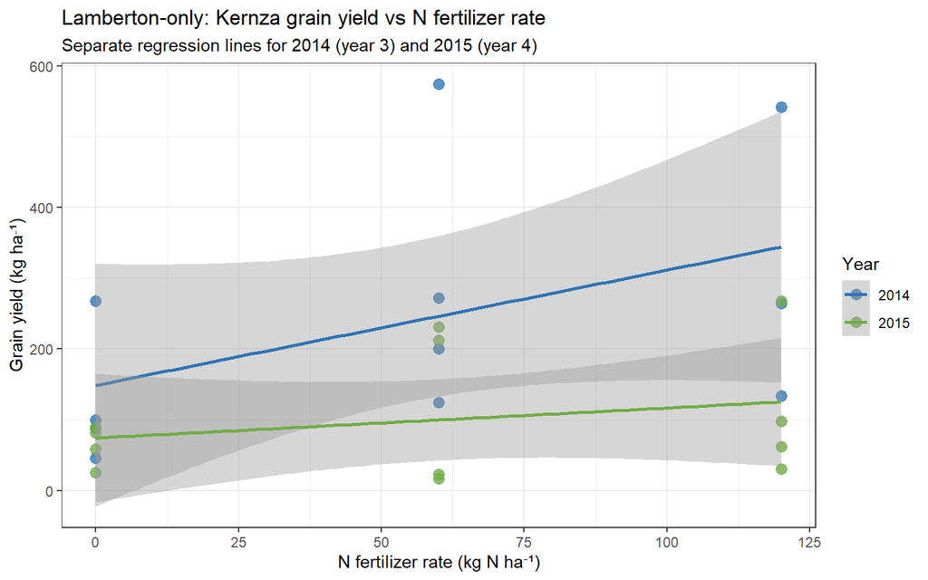

```r
ggplot(data_mono %>% filter(location == "Lamberton"),
       aes(x = n_fertilizer, y = grain_yield, color = year)) +
  geom_point(size = 3, alpha = 0.8) +
  geom_smooth(method = "lm", se = TRUE) +
  scale_color_manual(values = c("2014" = "#2E75B6", "2015" = "#70AD47")) +
  labs(
    title    = "Lamberton-only: Kernza grain yield vs N fertilizer rate",
    subtitle = "Separate regression lines for 2014 (year 3) and 2015 (year 4)",
    x        = "N fertilizer rate (kg N ha⁻¹)",
    y        = "Grain yield (kg ha⁻¹)",
    color    = "Year") +
  theme_bw()
```

### Regression Question 2: Where does the intercrop treatment fall on the yield ~ N rate curve?

**Hypothesis:** If the alfalfa intercrop provides a yield benefit through N fixation, the intercrop treatment (40 kg N ha⁻¹ synthetic + alfalfa-fixed N) should produce yields comparable to or exceeding monoculture plots receiving similar or higher synthetic N rates. If competition effects dominate between IWG and alfalfa, intercrop yields will fall below the monoculture regression line at 40 kg N ha⁻¹.

```r
reg2 <- lm(grain_yield ~ n_fertilizer*year*location, data = data_mono)
summary(reg2)
```

```
##
## Call:
## lm(formula = grain_yield ~ n_fertilizer * year * location, data = data_mono)
##
## Residuals:
##     Min      1Q  Median      3Q     Max
## -218.09  -62.41  -25.27   15.89  327.66
##
## Coefficients:
##                                       Estimate Std. Error t value Pr(>|t|)
## (Intercept)                           148.5789    54.6112   2.721  0.00977 **
## n_fertilizer                            1.6294     0.7547   2.159  0.03723 *
## year2015                              -74.2984    77.0306  -0.965  0.34088
## locationWaseca                       -108.2632    81.9169  -1.322  0.19420
## n_fertilizer:year2015                  -1.2048     1.0303  -1.169  0.24951
## n_fertilizer:locationWaseca            -0.8175     1.0673  -0.766  0.44841
## year2015:locationWaseca                78.5293   112.3077   0.699  0.48866
## n_fertilizer:year2015:locationWaseca    2.2069     1.4570   1.515  0.13813
## ---
## Signif. codes:  0 '***' 0.001 '**' 0.01 '*' 0.05 '.' 0.1 ' ' 1
##
## Residual standard error: 119 on 38 degrees of freedom
##   (2 observations deleted due to missingness)
## Multiple R-squared:  0.3808, Adjusted R-squared:  0.2667
## F-statistic: 3.338 on 7 and 38 DF,  p-value: 0.007181
```

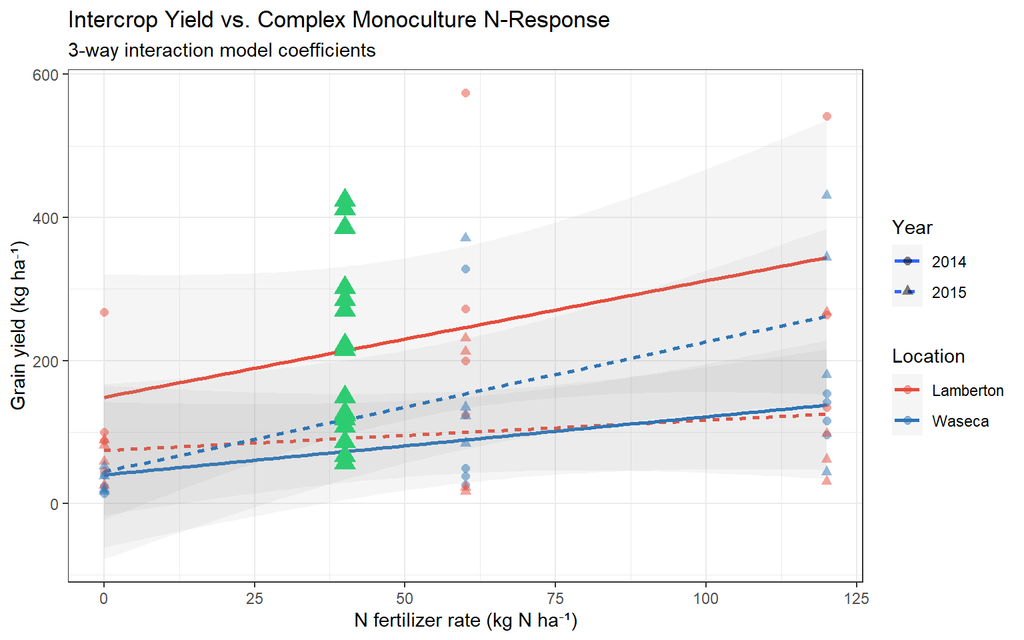

```r
ggplot() +
  # This matches your lm(grain_yield ~ n_fertilizer * year * location)
  geom_smooth(data = data_mono,
              aes(x = n_fertilizer, y = grain_yield, color = location, linetype = year),
              method = "lm", se = TRUE, alpha = 0.1) +

  # Monoculture points split by location and year to show the "spread"
  geom_point(data = data_mono,
             aes(x = n_fertilizer, y = grain_yield, color = location, shape = year),
             size = 2, alpha = 0.5) +

  # The Intercrop points (Green Triangles) sitting at 40kg N
  geom_point(data = data %>% filter(crops == "TLI/leg"),
             aes(x = n_fertilizer, y = grain_yield),
             color = "#2ECC71", size = 4, shape = 17) +

  # Custom colors to match your previous theme
  scale_color_manual(values = c("Waseca" = "#2E75B6", "Lamberton" = "#E74C3C")) +

  labs(
    title    = "Intercrop Yield vs. Complex Monoculture N-Response",
    subtitle = "3-way interaction model coefficients",
    x        = "N fertilizer rate (kg N ha⁻¹)",
    y        = "Grain yield (kg ha⁻¹)",
    color    = "Location",
    linetype = "Year",
    shape    = "Year") +
  theme_bw()
```

**Interpretation:** The three way interaction model reveals that the N-response slope for Waseca 2015 (Blue Dashed) was steeper than for Lamberton 2015 (Red Dashed), supporting the theory that the 2014 flood ‘reset’ the physiological budget. Furthermore, the intercrop treatment (Green Triangles) at 40 kg N consistently outperformed the predicted monoculture yield across most environments, demonstrating that biological N-fixation may be more efficient than synthetic N in aging perennial stands —

### Regression Question 3: Does lodging score increase with plant height?

**Hypothesis:** Taller plants are more prone to lodging due to a higher center of gravity and increased wind resistance. However Jungers et al. (2017) found that plant height did not explain additional variation in lodging beyond the effect of N fertilizer rate, suggesting stem diameter or composition may be more important than height alone.

```r
reg3 <- lm(lodging_score ~ plant_height, data = data)
summary(reg3)
```

```
##
## Call:
## lm(formula = lodging_score ~ plant_height, data = data)
##
## Residuals:
##     Min      1Q  Median      3Q     Max
## -2.6749 -1.0881 -0.2778  1.1129  3.4409
##
## Coefficients:
##              Estimate Std. Error t value Pr(>|t|)
## (Intercept)  -7.69526    2.36777  -3.250  0.00187 **
## plant_height  0.08039    0.01739   4.624 1.96e-05 ***
## ---
## Signif. codes:  0 '***' 0.001 '**' 0.01 '*' 0.05 '.' 0.1 ' ' 1
##
## Residual standard error: 1.497 on 62 degrees of freedom
## Multiple R-squared:  0.2564, Adjusted R-squared:  0.2444
## F-statistic: 21.38 on 1 and 62 DF,  p-value: 1.963e-05
```

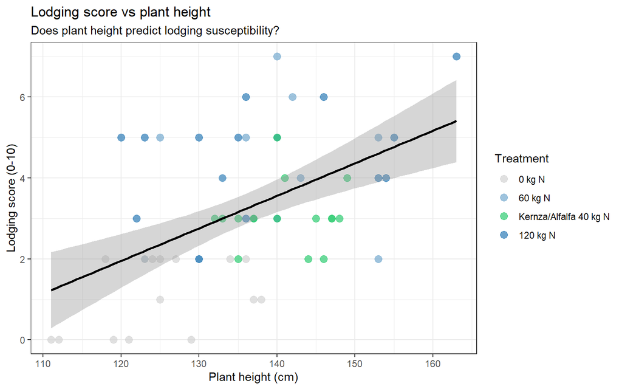

```r
ggplot(data, aes(x = plant_height, y = lodging_score)) +
  geom_point(aes(color = trt), size = 3, alpha = 0.7) +
  geom_smooth(method = "lm", se = TRUE, color = "black") +
  scale_color_manual(values = c(
    "0 kg N"                 = "#D3D3D3",
    "60 kg N"                = "#74A9CF",
    "Kernza/Alfalfa 40 kg N" = "#2ECC71",
    "120 kg N"               = "#2C7BB6")) +
  labs(
    title    = "Lodging score vs plant height",
    subtitle = "Does plant height predict lodging susceptibility?",
    x        = "Plant height (cm)",
    y        = "Lodging score (0-10)",
    color    = "Treatment") +
  theme_bw()
```

**Interpretation:**The lodging resilience of the Kernza/Alfalfa intercrop is likely a synergistic result of structural facilitation (physical support from alfalfa stems) and nutritional moderation. Unlike the 120 kg N treatment, which promotes rapid, structurally weak cell elongation, the intercrop system provides a slow release nitrogen source that may favor thicker cell walls and better lignification —

### Regression Question 4: Does alfalfa legume biomass correlate with Kernza straw yield in intercrop plots?

**Hypothesis:** Straw yield is examined in this analysis (rather than grain yield) because straw represents the vegetative biomass response to N availability. If alfalfa N fixation is the dominant intercrop benefit, greater alfalfa biomass should correlate with greater Kernza straw yield because more available N drives vegetative growth. Alternatively, if resource competition dominates the intercrop relationship, greater alfalfa biomass may correlate with reduced Kernza straw yield. Examining straw rather than grain isolates the vegetative response from reproductive allocation effects, which are addressed separately in the supplementary straw-to-grain conversion analysis below.

**Statistical limitations:** This analysis uses only the 16 intercrop plots (n = 4 per environment × 4 environments). Statistical power is limited, and the location and year effects are expected to dominate the raw correlation. The regression below controls for location and year.

```r
data_intercrop <- data %>%
  filter(crops == "TLI/leg", !is.na(legume_biomass), !is.na(grain_yield))

reg4 <- lm(iwg_straw_yield~legume_biomass*year*location, data=data_intercrop)
summary(reg4)
```

```
##
## Call:
## lm(formula = iwg_straw_yield ~ legume_biomass * year * location,
##     data = data_intercrop)
##
## Residuals:
##      Min       1Q   Median       3Q      Max
## -2060.13  -506.18   -61.19   709.58  2398.39
##
## Coefficients:
##                                        Estimate Std. Error t value Pr(>|t|)
## (Intercept)                            11501.92    2289.17   5.024  0.00102 **
## legume_biomass                           -31.61      28.97  -1.091  0.30689
## year2015                               -4756.34    2994.13  -1.589  0.15082
## locationWaseca                         -2061.29    2528.16  -0.815  0.43848
## legume_biomass:year2015                   35.84      29.47   1.216  0.25850
## legume_biomass:locationWaseca             18.17      96.01   0.189  0.85458
## year2015:locationWaseca                 7291.36    3527.94   2.067  0.07260 .
## legume_biomass:year2015:locationWaseca   -58.85     101.80  -0.578  0.57910
## ---
## Signif. codes:  0 '***' 0.001 '**' 0.01 '*' 0.05 '.' 0.1 ' ' 1
##
## Residual standard error: 1645 on 8 degrees of freedom
## Multiple R-squared:  0.4846, Adjusted R-squared:  0.03371
## F-statistic: 1.075 on 7 and 8 DF,  p-value: 0.4555
```

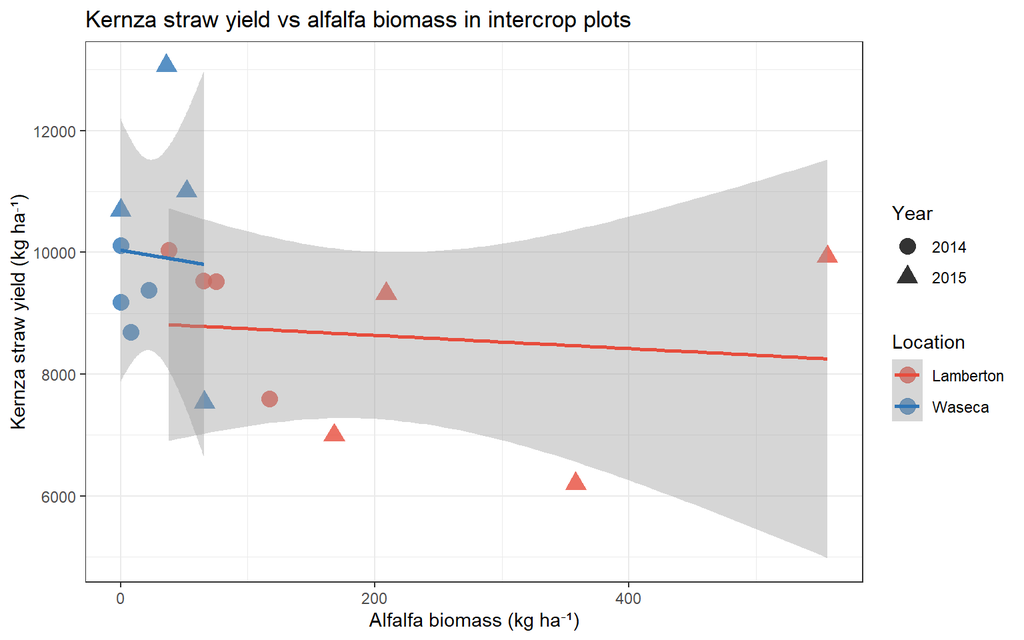

```r
ggplot(data_intercrop,
       aes(x = legume_biomass, y = iwg_straw_yield,
           color = location, shape = factor(year))) +
  geom_point(size = 4, alpha = 0.8) +
  geom_smooth(method = "lm", se = TRUE, aes(group = location)) +
  scale_color_manual(values = c("Waseca" = "#2E75B6",
                                 "Lamberton" = "#E74C3C")) +
  labs(
    title    = "Kernza straw yield vs alfalfa biomass in intercrop plots",
    x        = "Alfalfa biomass (kg ha⁻¹)",
    y        = "Kernza straw yield (kg ha⁻¹)",
    color    = "Location",
    shape    = "Year") +
  theme_bw()
```

```r
# Checking the grain yield to straw ratio to confirm the year two reduction
reg5 <- lm(grain_yield~iwg_straw_yield*location*year, data=data)
summary(reg5)
```

```
##
## Call:
## lm(formula = grain_yield ~ iwg_straw_yield * location * year,
##     data = data)
##
## Residuals:
##     Min      1Q  Median      3Q     Max
## -235.21  -55.82  -15.37   51.68  229.15
##
## Coefficients:
##                                           Estimate Std. Error t value Pr(>|t|)
## (Intercept)                             -1.388e+02  1.090e+02  -1.273 0.208771
## iwg_straw_yield                          4.167e-02  1.064e-02   3.916 0.000269
## locationWaseca                          -3.702e+01  1.589e+02  -0.233 0.816678
## year2015                                 1.135e+02  1.482e+02   0.766 0.447328
## iwg_straw_yield:locationWaseca          -7.603e-03  1.719e-02  -0.442 0.660106
## iwg_straw_yield:year2015                -2.461e-02  1.640e-02  -1.501 0.139642
## locationWaseca:year2015                 -1.975e+00  2.082e+02  -0.009 0.992467
## iwg_straw_yield:locationWaseca:year2015  1.870e-02  2.350e-02   0.796 0.429893
##
## (Intercept)
## iwg_straw_yield                         ***
## locationWaseca
## year2015
## iwg_straw_yield:locationWaseca
## iwg_straw_yield:year2015
## locationWaseca:year2015
## iwg_straw_yield:locationWaseca:year2015
## ---
## Signif. codes:  0 '***' 0.001 '**' 0.01 '*' 0.05 '.' 0.1 ' ' 1
##
## Residual standard error: 100.7 on 51 degrees of freedom
##   (5 observations deleted due to missingness)
## Multiple R-squared:  0.5389, Adjusted R-squared:  0.4756
## F-statistic: 8.515 on 7 and 51 DF,  p-value: 7.197e-07
```

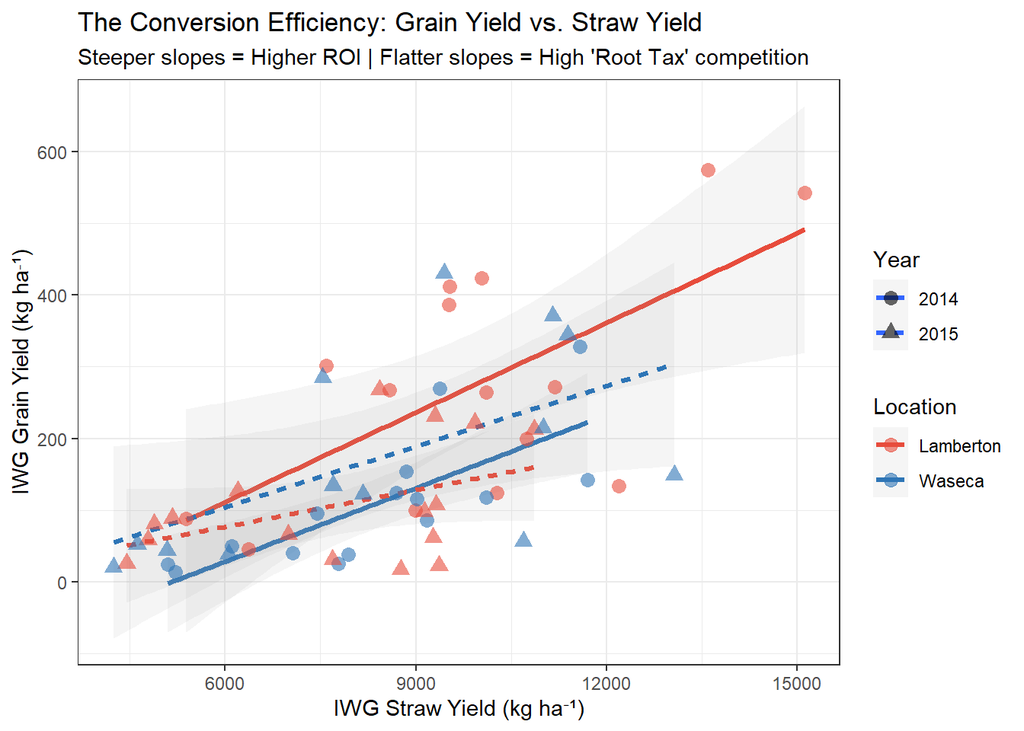

```r
ggplot(data, aes(x = iwg_straw_yield, y = grain_yield, color = location)) +
  # This matches your lm(grain_yield ~ iwg_straw_yield * location * year)
  geom_smooth(method = "lm", aes(linetype = year), se = TRUE, alpha = 0.1, size = 1.2) +

  # Individual plot observations
  geom_point(aes(shape = year), size = 3, alpha = 0.6) +

  # Custom colors to stay consistent with your theme
  scale_color_manual(values = c("Waseca" = "#2E75B6", "Lamberton" = "#E74C3C")) +

  labs(
    title    = "The Conversion Efficiency: Grain Yield vs. Straw Yield",
    subtitle = "Steeper slopes = Higher ROI | Flatter slopes = High 'Root Tax' competition",
    x        = "IWG Straw Yield (kg ha⁻¹)",
    y        = "IWG Grain Yield (kg ha⁻¹)",
    color    = "Location",
    shape    = "Year",
    linetype = "Year") +
  theme_bw()
```

## Summary of Findings

```r
tibble(
  Question = c(
    "ANOVA Q1: Treatment × environment effect on grain yield",
    "ANOVA Q2: Treatment effect on plant height (with grain yield correlation)",
    "Regression Q1: Grain yield ~ N fertilizer rate (monoculture, with Lamberton-only supplementary)",
    "Regression Q2: Intercrop position on yield curve",
    "Regression Q3: Lodging score ~ plant height",
    "Regression Q4: Kernza straw yield ~ alfalfa legume biomass (intercrop plots, with grain:straw efficiency)"
  ),
  `Response Variable` = c(
    "grain_yield", "plant_height",
    "grain_yield", "grain_yield", "lodging_score", "iwg_straw_yield / grain_yield"
  )
) %>%
  kable(caption = "Summary of research questions and response variables")
```

Summary of research questions and response variables

| Question | Response Variable |
| --- | --- |
| ANOVA Q1: Treatment × environment effect on grain yield | grain_yield |
| ANOVA Q2: Treatment effect on plant height (with grain yield correlation) | plant_height |
| Regression Q1: Grain yield ~ N fertilizer rate (monoculture, with Lamberton-only supplementary) | grain_yield |
| Regression Q2: Intercrop position on yield curve | grain_yield |
| Regression Q3: Lodging score ~ plant height | lodging_score |
| Regression Q4: Kernza straw yield ~ alfalfa legume biomass (intercrop plots, with grain:straw efficiency) | iwg_straw_yield / grain_yield |

## Future Directions

### Context: Documented June 2014 flooding at Waseca

The opposite yield trajectories between Waseca (2014→2015: +47% grain yield) and Lamberton (2014→2015: -49% to -66% grain yield across treatments) are the most striking pattern in this dataset. Weather records clarify a key driver at Waseca: June 2014 was the wettest month in Minnesota state history, with Waseca receiving 12.31 inches of rainfall is approximately four times the historical June average (Minnesota DNR 2014). Multiple flash flooding events affected Waseca County during the month, with flooding documented by National Weather Service alerts. The flooding occurred during the critical stem elongation and early reproductive development stages of Kernza on the poorly drained Webster clay loam soil, producing prolonged saturated and anaerobic conditions. The 2014 Waseca yields therefore represent suppressed yields under a documented extreme flooding event rather than typical year 3 Kernza performance.

The well-documented year 1-to-year 2 grain yield decline in Kernza stands remains mechanistically unresolved and is identified as a key challenge for perennial grain crop development (Cattani & Asselin 2018; De Pauw et al. 2022). One plausible hypothesis emerges from established principles of perennial grass physiology.

Root maintenance respiration in perennial plants can consume over 50% of the carbon utilized within the root system (Eissenstat 1993). Because this maintenance cost scales with absolute root biomass, a larger year 2 Kernza root system would impose a substantially higher absolute carbon demand than a smaller year 1 system, even if proportional allocation rules remained unchanged. Similarly, nitrogen remobilization from vegetative tissues to developing grain (accounting for 65-90% of grain N in cereals; Hu et al. 2016) must compete with N demands from an expanding root system.

Under this source-sink competition framework, the year 1-to-2 yield decline may result from increased absolute carbon and nitrogen consumption by root maintenance rather than from changes in allocation priorities. The plant’s photosynthetic capacity remains similar, but a larger fraction of fixed photosynthate and cycled nitrogen is consumed by root maintenance before it becomes available for grain filling.

**Testable predictions:**

- Root biomass should increase substantially between year 1 and year 2 Kernza stands (already documented by Jungers and Gutknecht)
- Absolute carbon allocation to root maintenance respiration should increase proportionally with root biomass
- Grain yield should correlate inversely with root maintenance carbon demand across stand ages
- Nitrogen remobilization efficiency to grain should decrease as root system N sink strength increases

**Methods:** Destructive root biomass sampling, root respiration measurements (chamber or isotope-tracer methods), whole-plant carbon allocation studies using 13C labeling, and plant tissue N analysis at key phenological stages. These methods are established in related perennial grass research (Carbone et al. 2007; Yao and Chen 2019) and transferable to Kernza.

**Status in literature:** No published study has directly tested this relationship in Kernza. Existing Kernza research documents root biomass increases with stand age but frames this as beneficial for soil carbon storage rather than as a potential yield-limiting cost. This represents a specific, tractable research gap.

This priority is contingent on Priority 1 findings. If root biomass accumulation is confirmed as a significant contributor to yield decline, identifying regulatory pathways that control root biomass development could inform breeding targets for improved yield stability across years.

The 2014 Waseca flooding provides a natural experimental context. The flooding reduced grain yield while apparently limiting normal root expansion. Understanding the molecular basis of this response has implications for both site selection (Kernza is promoted for marginal sites that may include poorly drained areas) and breeding for waterlogging tolerance.

**Approach:** Controlled waterlogging experiments using established methods (container flooding, hydroponic hypoxia, rhizotrons; Barickman et al. 2019; Kong et al. 2022) could recreate the 2014 Waseca conditions in a controlled setting. Comparison of root growth, development, and architecture between stressed and unstressed plants would provide the phenotypic baseline. If phenotypic differences are substantial, targeted gene expression analysis could investigate candidate pathways including hypoxia response (ERF-VII transcription factors), root meristem regulation, and carbohydrate allocation signaling.

**Research sequence rationale:** Priority 1 must precede Priority 2 because phenotypic characterization of the root-yield relationship provides the foundation for any molecular investigation. Investing in gene expression work before confirming the phenotypic relationship risks targeting the wrong mechanism. —

*Data wrangling and QA/QC fully documented in `data_wrangling.Rmd`.*  
*Reference: Jungers et al. 2017. Agron. J. 109:462–472.*